# Structural topic models for enriching quantitative text analysis material available at https://github.com/cbpuschmann/stm_ic2s2

# Model validation and interactively exploring STM models

## Interpreting structural topic models - topic proportions

- `plot.STM()` implements several options for model interpretation.
- *summary* plots show proportions and the most likely terms for each topic:

## Model interpretation - topic proportions

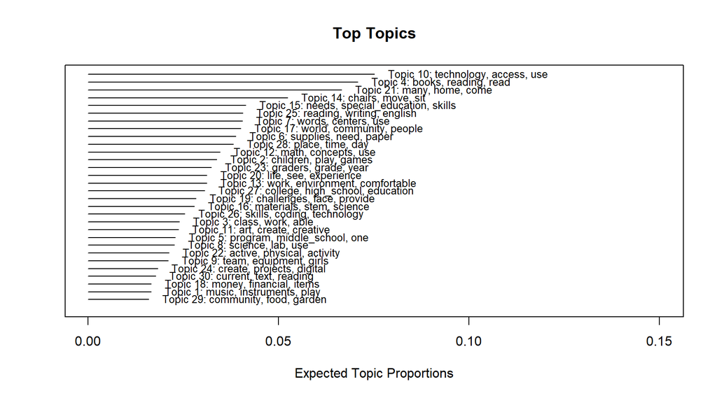

```r
plot.STM(stm_30, type = 'summary', text.cex = 0.8)
```

## Model interpretation - probability terms

`label` plots show terms for each topic with (again) the most likely terms as a default:

## Model interpretation - probability terms

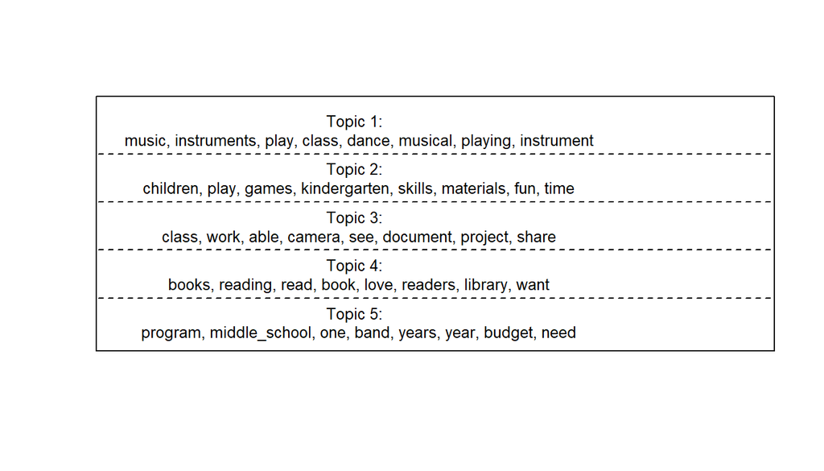

```r
plot.STM(stm_30, type = 'labels', n = 8,
         text.cex = 0.8, width = 100, topics = 1:5)
```

## Model interpretation - frex terms

One strength of STM is that it also offers other metrics for topic terms. `frex` terms are both frequent and exclusive to a topic.

## Model interpretation - frex terms

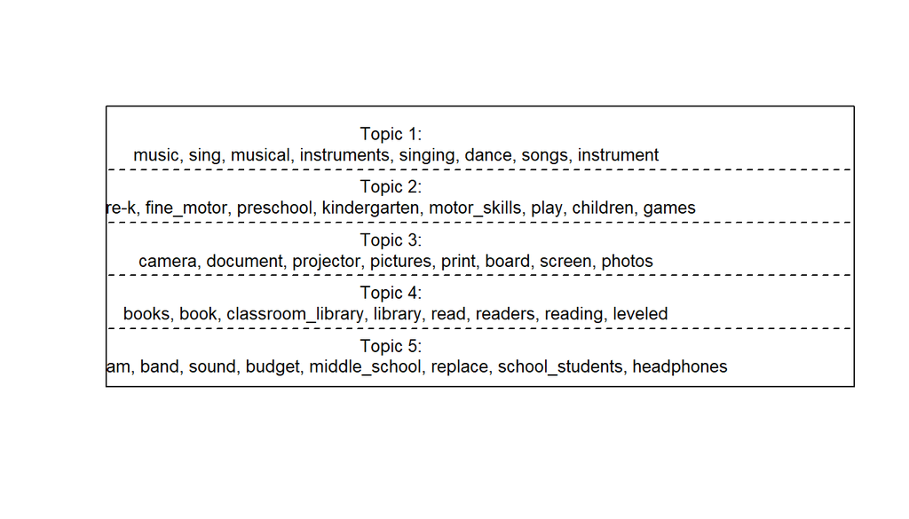

```r
plot.STM(stm_30, type = 'labels', n = 8, text.cex = 0.8,
         width = 100, topics = 1:5, labeltype = 'frex')
```

## Model interpretation - don’t rely on terms only

- Assigning labels for topics only by looking at the most likely terms is generally not a good idea
- Sometimes these terms contain domain-specific stop words. Sometimes they are hard to make sense of by themselves
- Recommendation:
  - use probability (most likely) terms
  - use frex terms
  - **qualitatively examine representative documents**

## Model interpretation - representative documents

- STM allows to find representative (unprocessed) documents for each topic with `findThoughts()`, which can then be plotted with `plotQuote()`:

```r
thoughts <- findThoughts(stm_30,
     texts = out$meta$text, # unprocessed documents
     topics = 1:3,  n = 2) # topics and number of documents
```

## Model interpretation - representative documents

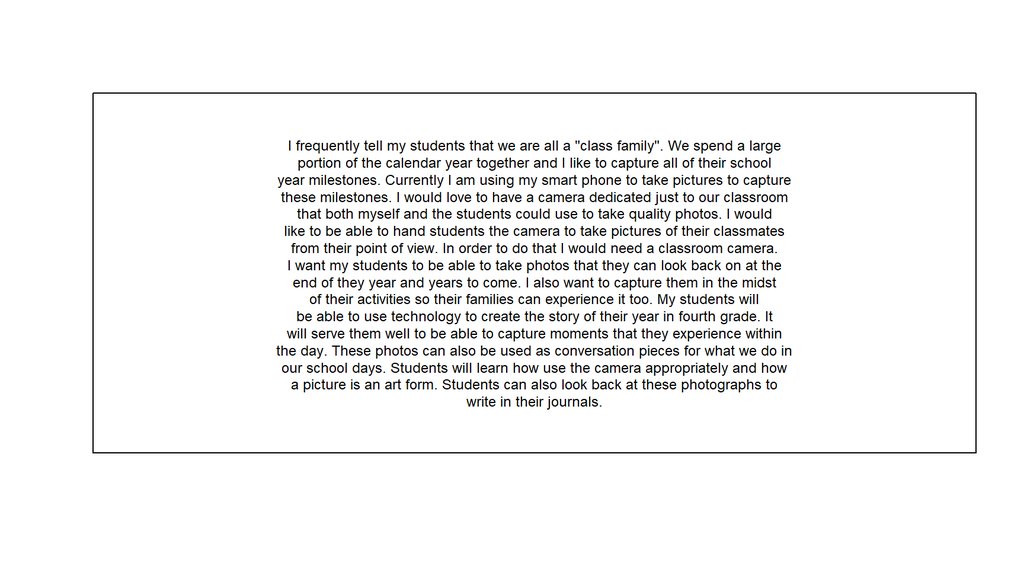

```r
plotQuote(thoughts$docs[[3]][1], # topic 3
          width = 80, text.cex = 0.75)
```

## Model intepretation - perspective plot

- It is also possible to visualize differences in word usage between two topics:

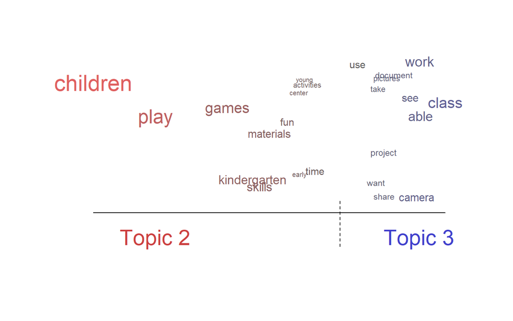

```r
plot.STM(stm_30, type = 'perspective', topics = c(2,3))
```

## Interactive model validation - stminsights

- You can interactively validate and explore structural topic models using the R package *stminsights*. What you need:
  - one or several stm models and corresponding effect estimates
  - the `out` object used to fit the models which includes documents, vocabulary and meta-data
- The example `stm_donor.RData` includes all required objects

```r
run_stminsights()
```

# Interpreting and visualizing prevalence and content effects

## Prevalence effects (stm package)

## Options for visualizing prevalence effects

- Prevalence covariates affect topic proportions
- They can be visualized in three ways:
  - `pointestimate`: pointestimates for categorical variables
  - `difference`: differences between topic proportions for two categories of one variable
  - `continuous`: line plots for continuous variables
- You can also visualize interaction effects if you integrated them in your STM model (see `?plot.estimateEffect()`)

## Prevalence effects - pointestimate

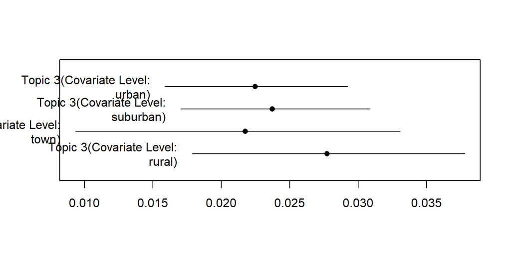

```r
plot.estimateEffect(stm_effects30, topic = 3,
            covariate = 'school_metro_type', method = 'pointestimate')
```

## Prevalence effects - difference

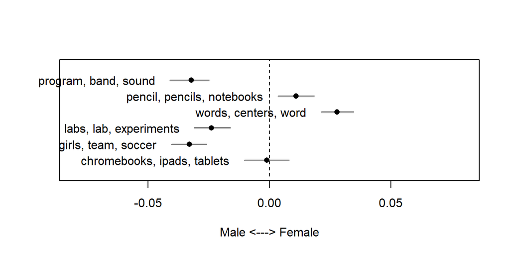

```r
plot.estimateEffect(stm_effects30, covariate = "gender",
                    topics = c(5:10), method = "difference",
                    model = stm_30, # to show labels alongside
                    cov.value1 = "Female", cov.value2 = "Male",
                    xlab = "Male <---> Female", xlim = c(-0.08, 0.08),
                    labeltype = "frex", n = 3,
                    width = 100,  verbose.labels = FALSE)
```

## Prevalence effects - continuous

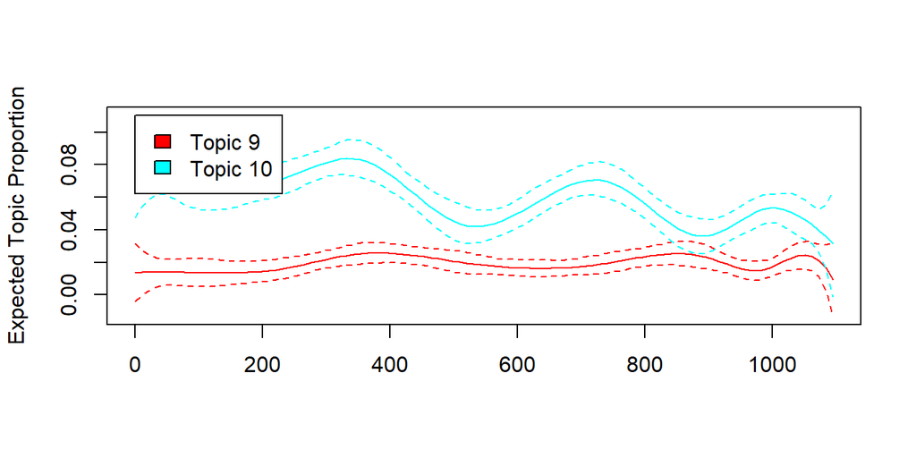

```r
plot.estimateEffect(stm_effects30, covariate = "date_num",
                    topics = c(9:10), method = "continuous")
```

## Prevalence effects with stminsights

- You can use `get_effects()` to store prevalence effects in a tidy data frame:

```r
gender_effects <- get_effects(estimates = stm_effects30,
                      variable = 'gender',
                      type = 'pointestimate')

date_effects <- get_effects(estimates = stm_effects30,
                      variable = 'date_num',
                      type = 'continuous')
```

- Afterwards, effects can for instance be visualized with `ggplot2`

## Prevalence effects with stminsights - categorical

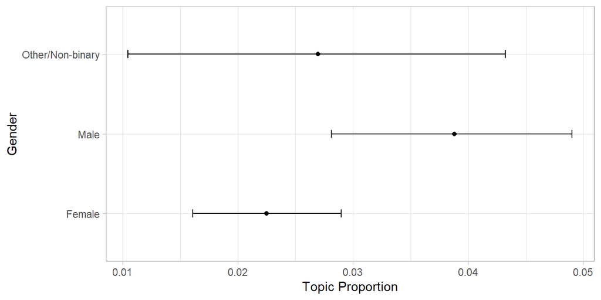

```r
gender_effects %>% filter(topic == 3) %>%
ggplot(aes(x = value, y = proportion)) + geom_point() +
 geom_errorbar(aes(ymin = lower, ymax = upper), width = 0.1) +
 coord_flip() + labs(x = 'Gender', y = 'Topic Proportion')
```

## Prevalence effects with stminsights - continuous (date)

- STM doesn’t work well with visualzing continous date variables.
- For visualization purposes, we can convert our numeric date identifier back to original form:

```r
date_effects <- date_effects %>%
  mutate(date_num = round(value, 0))  %>%
  left_join(out$meta %>% select(date, date_num)) %>% distinct()
```

## Prevalence effects with stminsights - continuous (date)

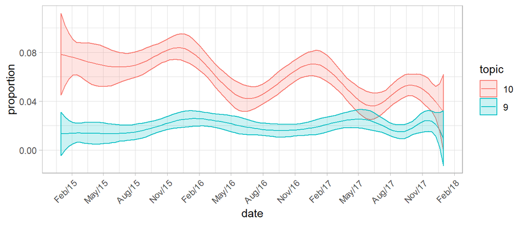

```r
date_effects %>% filter(topic %in% c(9,10)) %>%
       ggplot(aes(x = date, y = proportion,
                  group = topic, color = topic, fill = topic)) +
  geom_line() + scale_x_date(date_break = '3 months', date_labels = "%b/%y") +
  geom_ribbon(aes(ymin = lower, ymax = upper), alpha = 0.2) +
  theme(axis.text.x = element_text(angle = 45, hjust = 1))
```

## STM content effects

- Content effects allow covariates to affect word distributions **within a topic** (e.g. female teachers talk differently about sports in comparison to male teachers). Example model formula: `content = ~ gender`
- This feature is powerful but comes with some disadvantages:
  - You can only use one discrete variable for content effects
  - Interpreting the model is more complicated (see `labelTopics()` and `sageLabels()`)
  - We will focus on visualizing content effects with `perspective` plots

## Fitting content models

- Content effects can (but do not have to) be combined with prevalence effects. We fit a model with 20 topics and teacher gender as content covariate
- Important note: this as a new model and can show different results, even if you compare it to a model with the same number of topics

```r
stm_20_content <- stm(documents = out$documents,
      vocab = out$vocab,
      data = out$meta,
      K = 20,
      prevalence = ~ school_metro_type + gender + s(date_num),
      content = ~ gender,
      verbose = FALSE) # show progress
stm_effects20 <- estimateEffect(1:20 ~ school_metro_type +
      gender + s(date_num),
      stmobj = stm_20_content, metadata = out$meta)
save(stm_20_content, stm_effects20,file =  "data/stm_donor_content.RData")
```

## Load content model

```r
load("data/stm_donor_content.RData") # reload data
```

## Visalizing content effects

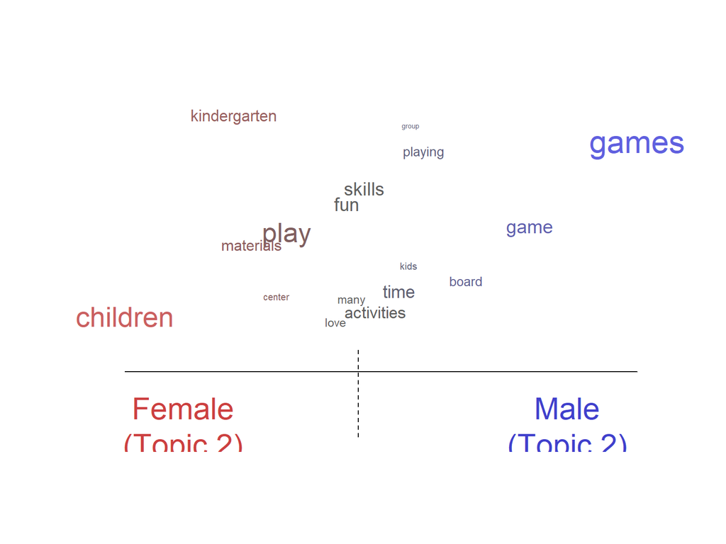

```r
plot.STM(stm_20_content, topics = c(2), type = 'perspectives',
         covarlevels = c('Female', 'Male'))
```

# Open coding session

## Open coding session - your turn

- For the open coding session, you can choose to either play around with data and models from the tutorial, or try fitting stm models on your own data
- We will be around to help you out and answer questions

# Appendix - code to play around with

## Appendix - more about comparing models

As for statistical diagnostics, the STM authors recommend to inspect semantic coherence and exclusivity (see [STM vignette](https://github.com/bstewart/stm/blob/master/inst/doc/stmVignette.pdf?raw=true)):

- Semantic coherence is is maximized when the most probable words in a given topic frequently co-occur together
- Exclusivity (FREX) is maximized when a topic includes many exclusive terms
- Coherence and exclusivity cannot be compared for models with content effects

## Appendix - fitting another model for comparisons

```r
stm_10 <- stm(documents = out$documents,
      vocab = out$vocab,
      data = out$meta,
      K = 10,
      prevalence = ~ school_metro_type * s(date_num), # interaction
      verbose = FALSE) # show progress

stm_effects10 <- estimateEffect(1:10 ~ school_metro_type +
      gender * s(date_num),
      stmobj = stm_10, metadata = out$meta)

save(stm_10, stm_effects10, file =  "data/stm_donor_int.RData")
```

```r
load("data/stm_donor_int.RData") # reload data
```

## Appendix - calculating diagnostics (stminsights)

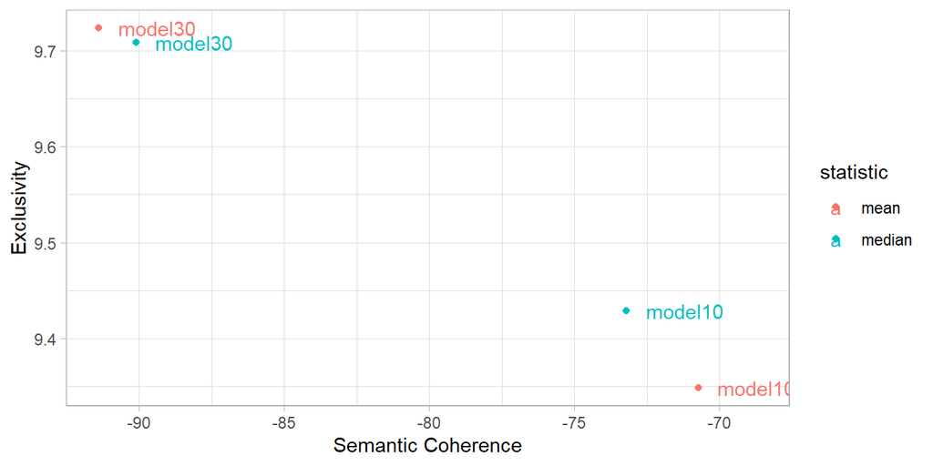

```r
diag <- get_diag(models =  list(
           model10 = stm_10, model30 = stm_30), out)
diag %>%
  ggplot(aes(x = coherence, y = exclusivity, color = statistic))  +
  geom_text(aes(label = name), nudge_x = 2) + geom_point() +
  labs(x = 'Semantic Coherence', y = 'Exclusivity')
```

## Appendix - correlation networks (stminsights)

```r
library(ggraph)
stm_corrs <- get_network(model = stm_30,
                         method = 'simple', # correlation criterion,
                         cutoff = 0.05, # minimum correlation
                         labels = paste('T', 1:30),
                         cutiso = FALSE) # isolated nodes
```

## Appendix - correlation networks (stminsights)

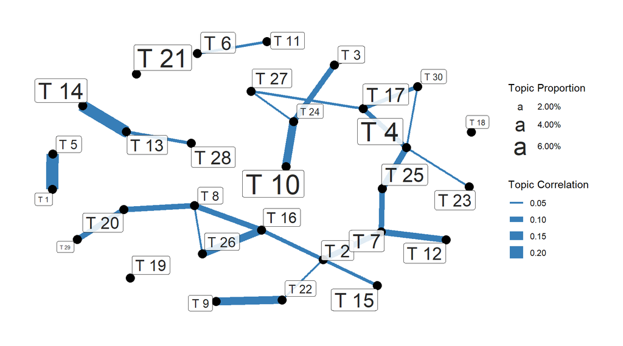

```r
ggraph(stm_corrs, layout = 'fr') + geom_edge_link(
    aes(edge_width = weight), label_colour = '#fc8d62',
    edge_colour = '#377eb8') + geom_node_point(size = 4, colour = 'black')  +
  geom_node_label(aes(label = name, size = props),
                    colour = 'black',  repel = TRUE, alpha = 0.85) +
  scale_size(range = c(2, 10), labels = scales::percent) +
  labs(size = 'Topic Proportion',  edge_width = 'Topic Correlation') + theme_graph()
```